# Análisis del efecto de Mediación

Daniel Fernandez

2024-05-09

# 1 ¿Qué es la medicación?

El análisis de mediación pone a prueba una hipotética cadena causal en la que una variable X afecta a una segunda variable M y, a su vez, esa variable afecta a una tercera variable Y. Los mediadores describen el cómo o el porqué de una relación (normalmente bien establecida) entre otras dos variables y a veces se denominan variables intermedias, ya que suelen describir el proceso a través del cual se produce un efecto. A veces también se denominan efectos indirectos. Por ejemplo, las personas con mayores ingresos tienden a vivir más, pero este efecto se explica por la influencia mediadora de tener acceso a una mejor atención sanitaria.

En R, este tipo de análisis puede realizarse de dos formas: El método de efectos indirectos en 4 pasos de Baron & Kenny (1986) y el más reciente paquete *mediation* (Tingley, Yamamoto, Hirose, Keele, & Imai, 2014). El método de Baron y Kelly es uno de los métodos originales para probar la mediación, pero tiende a tener una potencia estadística baja. Se trata en este capítulo porque proporciona un enfoque muy claro para establecer relaciones entre variables y los revisores todavía lo solicitan ocasionalmente. Sin embargo, el método del paquete *mediación* es muy recomendable como enfoque más flexible y estadísticamente potente.

## 1.1 Cómo empezar

Si es necesario, revise el capítulo sobre regresión. Los supuestos de las pruebas de regresión pueden comprobarse con *gvlma*. Puede cargar todas las librerías de abajo o cargarlas a medida que avanza. Revise la sección de ayuda de cualquier paquete con el que no esté familiarizado *?? nombredelpaquete*.

```r
library(mediation) #Mediation package
library(rockchalk) #Graphing simple slopes; moderation
library(multilevel) #Sobel Test
library(bda) #Another Sobel Test option
library(gvlma) #Testing Model Assumptions
library(stargazer) #Handy regression tables

#Useful Help
?lm
?mediation
?rockchalk
?stargazer

#Optional packages
library(QuantPsyc)
library(pequod)  # devtools::install_github("cran/pequod")
?moderate.lm
?pequod
```

```
## No documentation for 'pequod' in specified packages and libraries:
## you could try '??pequod'
```

# 2 Análisis de mediación

La mediación prueba si los efectos de X (la variable independiente) sobre Y (la variable dependiente) operan a través de una tercera variable, M (el mediador). De este modo, los mediadores explican la relación causal entre dos variables o “cómo” funciona la relación, por lo que es un método muy popular en la investigación en salud.

Tanto la mediación como la moderación suponen que hay poco o ningún error de medición en la variable mediadora/moderadora y que la VD **no CAUSÓ** la mediadora/moderadora. Si es probable que el error del mediador sea alto, los investigadores deben recopilar múltiples indicadores del constructo y utilizar SEM para estimar variables latentes. Las formas más seguras de asegurarse de que su mediador no está causado por su VD son manipular experimentalmente la variable o recoger la medida de su mediador antes de introducir su IV.

Efecto de mediación total

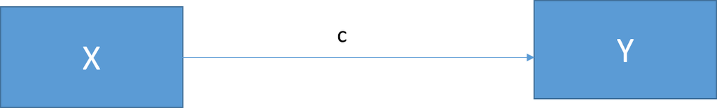

Efecto de mediación parcial

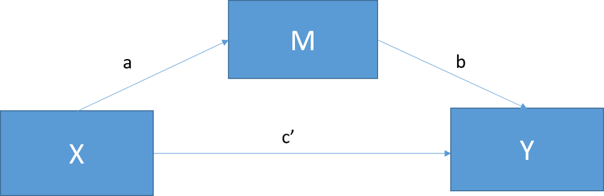

- c = el efecto total de X sobre Y
- c = c’ + ab
- c’= el efecto directo de X sobre Y después de controlar por M; c’=c-ab
- ab= efecto indirecto de X sobre Y

Lo anterior muestra el modelo de mediación estándar. La mediación perfecta se produce cuando el efecto de X sobre Y disminuye a 0 con M en el modelo. La mediación parcial se produce cuando el efecto de X sobre Y disminuye en una cantidad no trivial (la cantidad real es objeto de debate) con M en el modelo.

## 2.1 Ejemplo de datos de mediación

Establezca un directorio de trabajo apropiado y genere el siguiente conjunto de datos.

En este ejemplo diremos que estamos interesados en saber si el número de horas desde el amanecer (X) afecta las calificaciones subjetivas de vigilia (Y) de 100 estudiantes de posgrado a través del consumo de café (M).

Tenga en cuenta que aquí estamos creando intencionalmente un efecto de mediación (porque las estadísticas siempre son más divertidas si tenemos algo que encontrar) y lo hacemos a continuación creando M para que esté relacionado con X e Y para que esté relacionado con M. Esto crea la cadena causal para que nuestro análisis la analice.

```r
#setwd("user location") #Working directory
set.seed(123) #Standardizes the numbers generated by rnorm; see Chapter 5
N <- 100 #Number of participants; graduate students
X <- rnorm(N, 175, 7) #IV; hours since dawn
M <- 0.7*X + rnorm(N, 0, 5) #Suspected mediator; coffee consumption
Y <- 0.4*M + rnorm(N, 0, 5) #DV; wakefulness
Meddata <- data.frame(X, M, Y)
```

## 2.2 Método 1: Baron & Kenny

Este es el método original de 4 pasos utilizado para describir un efecto de mediación. Los pasos 1 y 2 utilizan la regresión lineal básica, mientras que los pasos 3 y 4 utilizan la regresión múltiple.

Los pasos: 1. Estimar la relación entre X en Y (horas desde el amanecer en grado de vigilia) -La ruta “c” debe ser significativamente diferente de 0; debe tener un efecto total entre el IV y el VD

2. Estimar la relación entre X y M (horas transcurridas desde el amanecer sobre el consumo de café) -La ruta “a” debe ser significativamente diferente de 0; el IV y el mediador deben estar relacionados.
3. 3. Estimar la relación entre M y Y controlando por X (consumo de café sobre la vigilia, controlando por las horas desde el amanecer) -La ruta “b” debe ser significativamente diferente de 0; mediador y VD deben estar relacionados. -El efecto de X sobre Y disminuye con la inclusión de M en el modelo.
4. Estimar la relación entre Y sobre X controlando por M (vigilia sobre horas desde el amanecer, controlando por consumo de café) -Debe ser no significativa y cercana a 0.

```r
#1. Total Effect
fit <- lm(Y ~ X, data=Meddata)
summary(fit)
```

```
##
## Call:
## lm(formula = Y ~ X, data = Meddata)
##
## Residuals:
##     Min      1Q  Median      3Q     Max
## -10.917  -3.738  -0.259   2.910  12.540
##
## Coefficients:
##             Estimate Std. Error t value Pr(>|t|)
## (Intercept) 19.88368   14.26371   1.394   0.1665
## X            0.16899    0.08116   2.082   0.0399 *
## ---
## Signif. codes:  0 '***' 0.001 '**' 0.01 '*' 0.05 '.' 0.1 ' ' 1
##
## Residual standard error: 5.16 on 98 degrees of freedom
## Multiple R-squared:  0.04237,    Adjusted R-squared:  0.0326
## F-statistic: 4.336 on 1 and 98 DF,  p-value: 0.03993
```

```r
#2. Path A (X on M)
fita <- lm(M ~ X, data=Meddata)
summary(fita)
```

```
##
## Call:
## lm(formula = M ~ X, data = Meddata)
##
## Residuals:
##     Min      1Q  Median      3Q     Max
## -9.5367 -3.4175 -0.4375  2.9032 16.4520
##
## Coefficients:
##             Estimate Std. Error t value Pr(>|t|)
## (Intercept)  6.04494   13.41692   0.451    0.653
## X            0.66252    0.07634   8.678 8.87e-14 ***
## ---
## Signif. codes:  0 '***' 0.001 '**' 0.01 '*' 0.05 '.' 0.1 ' ' 1
##
## Residual standard error: 4.854 on 98 degrees of freedom
## Multiple R-squared:  0.4346, Adjusted R-squared:  0.4288
## F-statistic: 75.31 on 1 and 98 DF,  p-value: 8.872e-14
```

```r
#3. Path B (M on Y, controlling for X)
fitb <- lm(Y ~ M + X, data=Meddata)
summary(fitb)
```

```
##
## Call:
## lm(formula = Y ~ M + X, data = Meddata)
##
## Residuals:
##     Min      1Q  Median      3Q     Max
## -9.3651 -3.3037 -0.6222  3.1068 10.3991
##
## Coefficients:
##             Estimate Std. Error t value Pr(>|t|)
## (Intercept) 17.32177   13.16216   1.316    0.191
## M            0.42381    0.09899   4.281 4.37e-05 ***
## X           -0.11179    0.09949  -1.124    0.264
## ---
## Signif. codes:  0 '***' 0.001 '**' 0.01 '*' 0.05 '.' 0.1 ' ' 1
##
## Residual standard error: 4.756 on 97 degrees of freedom
## Multiple R-squared:  0.1946, Adjusted R-squared:  0.1779
## F-statistic: 11.72 on 2 and 97 DF,  p-value: 2.771e-05
```

```r
#4. Reversed Path C (Y on X, controlling for M)
fitc <- lm(X ~ Y + M, data=Meddata)
summary(fitc)
```

```
##
## Call:
## lm(formula = X ~ Y + M, data = Meddata)
##
## Residuals:
##     Min      1Q  Median      3Q     Max
## -14.438  -2.573  -0.030   3.010  11.779
##
## Coefficients:
##             Estimate Std. Error t value Pr(>|t|)
## (Intercept) 96.11234    9.27663  10.361  < 2e-16 ***
## Y           -0.11493    0.10229  -1.124    0.264
## M            0.69619    0.08356   8.332 5.27e-13 ***
## ---
## Signif. codes:  0 '***' 0.001 '**' 0.01 '*' 0.05 '.' 0.1 ' ' 1
##
## Residual standard error: 4.823 on 97 degrees of freedom
## Multiple R-squared:  0.4418, Adjusted R-squared:  0.4303
## F-statistic: 38.39 on 2 and 97 DF,  p-value: 5.233e-13
```

```r
#Summary Table
stargazer(fit, fita, fitb, fitc, type = "text", title = "Baron and Kenny Method")
```

```
##
## Baron and Kenny Method
## =============================================================================================================
##                                                        Dependent variable:
##                     -----------------------------------------------------------------------------------------
##                              Y                     M                      Y                      X
##                             (1)                   (2)                    (3)                    (4)
## -------------------------------------------------------------------------------------------------------------
## Y                                                                                              -0.115
##                                                                                               (0.102)
##
## M                                                                      0.424***               0.696***
##                                                                        (0.099)                (0.084)
##
## X                         0.169**               0.663***                -0.112
##                           (0.081)               (0.076)                (0.099)
##
## Constant                   19.884                6.045                  17.322               96.112***
##                           (14.264)              (13.417)               (13.162)               (9.277)
##
## -------------------------------------------------------------------------------------------------------------
## Observations                100                   100                    100                    100
## R2                         0.042                 0.435                  0.195                  0.442
## Adjusted R2                0.033                 0.429                  0.178                  0.430
## Residual Std. Error   5.160 (df = 98)       4.854 (df = 98)        4.756 (df = 97)        4.823 (df = 97)
## F Statistic         4.336** (df = 1; 98) 75.313*** (df = 1; 98) 11.715*** (df = 2; 97) 38.389*** (df = 2; 97)
## =============================================================================================================
## Note:                                                                             *p<0.1; **p<0.05; ***p<0.01
```

## 2.3 Interpretación de los resultados de Barron & Kenny

Aquí encontramos que nuestro modelo de efecto total muestra una relación positiva significativa entre las horas desde el amanecer (X) y la vigilia (Y). Nuestro modelo Ruta A muestra que las horas desde la caída (X) también están relacionadas positivamente con el consumo de café (M). Nuestro modelo Path B luego muestra que el consumo de café (M) predice positivamente la vigilia (Y) cuando se controla por horas desde el amanecer (X). Finalmente, la vigilia (Y) no predice las horas desde el amanecer (X) cuando se controla el consumo de café (M).

Dado que la relación entre las horas desde el amanecer y la vigilia ya no es significativa cuando se controla el consumo de café, esto sugiere que el consumo de café, de hecho, media esta relación. Sin embargo, este método por sí solo no permite una prueba formal del efecto indirecto, por lo que no sabemos si el cambio en esta relación es realmente significativo.

Hay dos métodos principales para probar formalmente la importancia de la prueba indirecta: la prueba de Sobel y el bootstrapping (cubiertos bajo el método de mediación ).

```r
#Sobel Test
library(multilevel)
?sobel
sobel(Meddata$X, Meddata$M, Meddata$Y)
```

```
## $`Mod1: Y~X`
##               Estimate Std. Error  t value   Pr(>|t|)
## (Intercept) 19.8836805 14.2637142 1.394004 0.16646905
## pred         0.1689931  0.0811601 2.082220 0.03992761
##
## $`Mod2: Y~X+M`
##               Estimate  Std. Error   t value     Pr(>|t|)
## (Intercept) 17.3217682 13.16215851  1.316028 1.912663e-01
## pred        -0.1117904  0.09949262 -1.123605 2.639537e-01
## med          0.4238113  0.09899469  4.281152 4.371472e-05
##
## $`Mod3: M~X`
##              Estimate  Std. Error   t value     Pr(>|t|)
## (Intercept) 6.0449365 13.41692114 0.4505457 6.533122e-01
## pred        0.6625203  0.07634187 8.6783345 8.871741e-14
##
## $Indirect.Effect
## [1] 0.2807836
##
## $SE
## [1] 0.07313234
##
## $z.value
## [1] 3.83939
##
## $N
## [1] 100
```

```r
#or
library(bda)
mediation.test(M,X,Y)
```

|  | Sobel | Aroian | Goodman |
| --- | --- | --- | --- |
| z.value | 3.8393902040 | 3.8190525305 | 3.8600562907 |
| p.value | 0.0001233403 | 0.0001339652 | 0.0001133609 |

La prueba de Sobel utiliza una prueba t especializada para determinar si hay una reducción significativa en el efecto de X sobre Y cuando M está presente. El uso de la función sobel del paquete multinivel le proporcionará tres de los modelos básicos que ejecutamos antes (Mod1 = Efecto total; Mod2 = Ruta B; y Mod3 = Ruta A), así como una estimación del efecto indirecto, el estándar. error de ese efecto y el valor z de ese efecto. Puede usar este valor para calcular su valor p o ejecutar la función mediation.test desde el paquete bda para recibir un valor p para esta estimación.

En este caso, ahora podemos confirmar que la relación entre las horas desde el amanecer y la sensación de vigilia está mediada significativamente por el consumo de café (z’ = 3,84, p < 0,001).

Sin embargo, la prueba de Sobel se considera en gran medida un método obsoleto, ya que supone que el efecto indirecto (ab) se distribuye normalmente y tiende a tener el poder adecuado sólo con tamaños de muestra grandes. Por lo tanto, nuevamente, se recomienda encarecidamente utilizar el método de arranque de mediación.

## 2.4 Método 2: El método *Mediation* Pacakge

Este paquete utiliza el método bootstrapping más reciente de Preacher & Hayes (2004) para abordar las limitaciones de potencia de la Prueba de Sobel. Este método calcula la estimación puntual del efecto indirecto (ab) sobre un gran número de muestras aleatorias (normalmente 1000), por lo que no asume que los datos se distribuyen normalmente y es especialmente más adecuado para tamaños de muestra pequeños que el método de Barron & Kenny.

Para ejecutar la función *media*, necesitaremos de nuevo un modelo de nuestro IV (horas transcurridas desde el amanecer), que prediga nuestro mediador (consumo de café) como nuestro modelo Path A anterior. También necesitaremos un modelo del efecto directo de nuestro IV (horas desde el amanecer) sobre nuestro VD (vigilia), al controlar nuestro mediador (consumo de café). A continuación, podemos utilizar *mediate* para simular repetidamente una comparación entre estos modelos y comprobar la importancia del efecto indirecto del consumo de café.

```r
#Mediate package
library(mediation)
?mediate
fitM <- lm(M ~ X,     data=Meddata) #IV on M; Hours since dawn predicting coffee consumption
fitY <- lm(Y ~ X + M, data=Meddata) #IV and M on DV; Hours since dawn and coffee predicting wakefulness
gvlma(fitM) #data is positively skewed; could log transform (see assumptions)
```

```
##
## Call:
## lm(formula = M ~ X, data = Meddata)
##
## Coefficients:
## (Intercept)            X
##      6.0449       0.6625
##
##
## ASSESSMENT OF THE LINEAR MODEL ASSUMPTIONS
## USING THE GLOBAL TEST ON 4 DEGREES-OF-FREEDOM:
## Level of Significance =  0.05
##
## Call:
##  gvlma(x = fitM)
##
##                    Value p-value                   Decision
## Global Stat        8.833 0.06542    Assumptions acceptable.
## Skewness           6.314 0.01198 Assumptions NOT satisfied!
## Kurtosis           1.219 0.26949    Assumptions acceptable.
## Link Function      1.076 0.29959    Assumptions acceptable.
## Heteroscedasticity 0.223 0.63674    Assumptions acceptable.
```

```r
gvlma(fitY)
```

```
##
## Call:
## lm(formula = Y ~ X + M, data = Meddata)
##
## Coefficients:
## (Intercept)            X            M
##     17.3218      -0.1118       0.4238
##
##
## ASSESSMENT OF THE LINEAR MODEL ASSUMPTIONS
## USING THE GLOBAL TEST ON 4 DEGREES-OF-FREEDOM:
## Level of Significance =  0.05
##
## Call:
##  gvlma(x = fitY)
##
##                      Value p-value                Decision
## Global Stat        3.41844  0.4904 Assumptions acceptable.
## Skewness           1.85648  0.1730 Assumptions acceptable.
## Kurtosis           0.77788  0.3778 Assumptions acceptable.
## Link Function      0.71512  0.3977 Assumptions acceptable.
## Heteroscedasticity 0.06896  0.7929 Assumptions acceptable.
```

```r
fitMed <- mediate(fitM, fitY, treat="X", mediator="M")
summary(fitMed)
```

```
##
## Causal Mediation Analysis
##
## Quasi-Bayesian Confidence Intervals
##
##                Estimate 95% CI Lower 95% CI Upper p-value
## ACME             0.2808       0.1437         0.42  <2e-16 ***
## ADE             -0.1133      -0.3116         0.09   0.258
## Total Effect     0.1674       0.0208         0.34   0.028 *
## Prop. Mediated   1.6428       0.5631         8.44   0.028 *
## ---
## Signif. codes:  0 '***' 0.001 '**' 0.01 '*' 0.05 '.' 0.1 ' ' 1
##
## Sample Size Used: 100
##
##
## Simulations: 1000
```

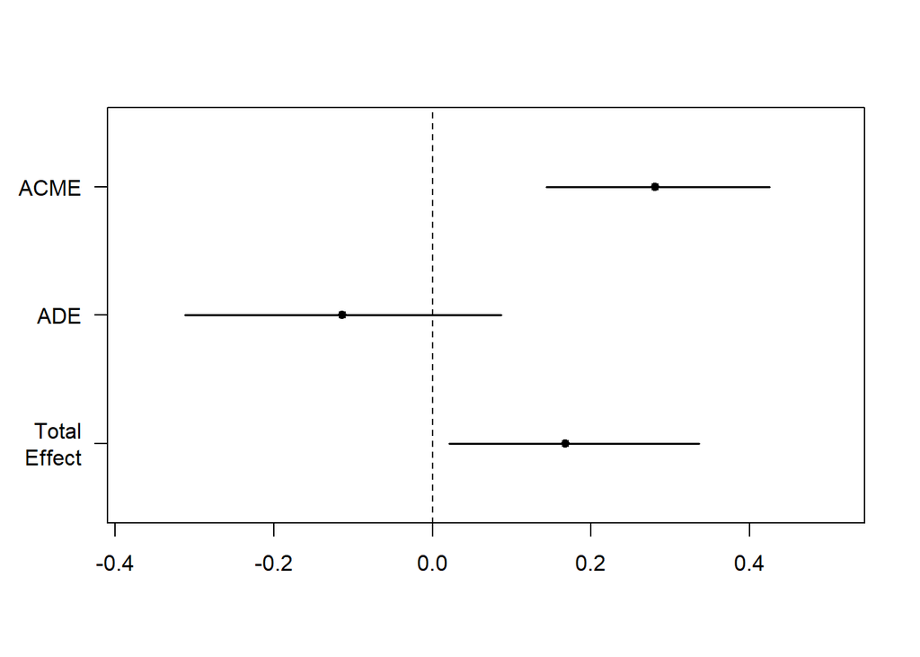

```r
plot(fitMed)
```

```r
#Bootstrap
fitMedBoot <- mediate(fitM, fitY, boot=TRUE, sims=999, treat="X", mediator="M")
summary(fitMedBoot)
```

```
##
## Causal Mediation Analysis
##
## Nonparametric Bootstrap Confidence Intervals with the Percentile Method
##
##                Estimate 95% CI Lower 95% CI Upper p-value
## ACME             0.2808       0.1409         0.42  <2e-16 ***
## ADE             -0.1118      -0.3080         0.12    0.31
## Total Effect     0.1690      -0.0123         0.34    0.07 .
## Prop. Mediated   1.6615      -3.7235        11.33    0.07 .
## ---
## Signif. codes:  0 '***' 0.001 '**' 0.01 '*' 0.05 '.' 0.1 ' ' 1
##
## Sample Size Used: 100
##
##
## Simulations: 999
```

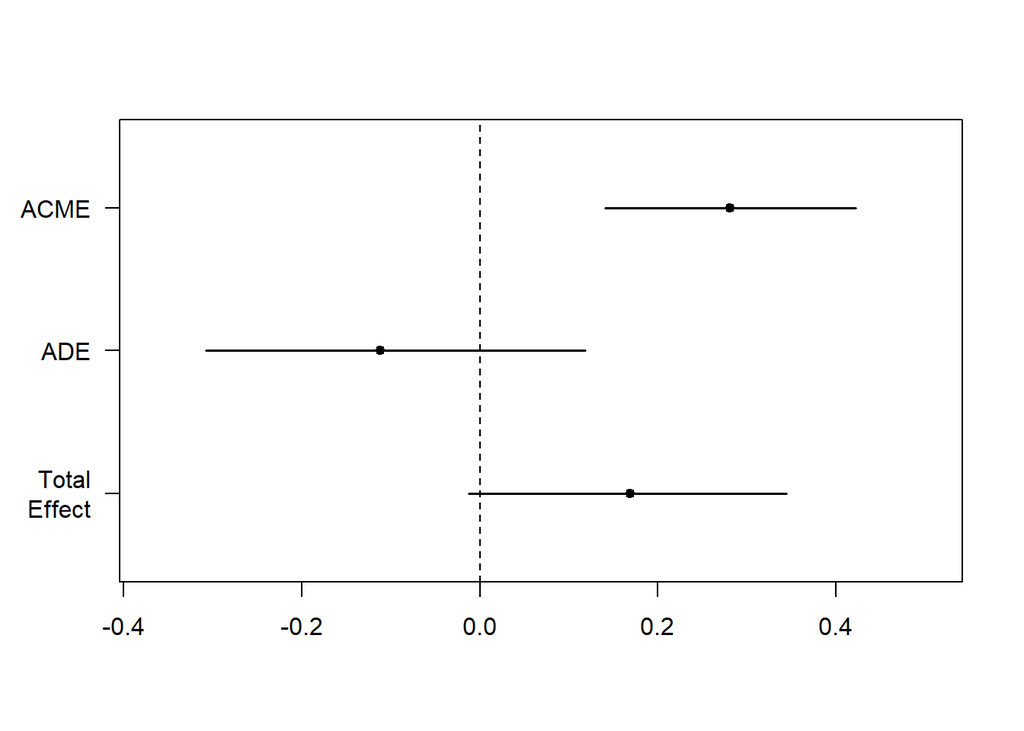

```r
plot(fitMedBoot)
```

## 2.5 Interpretación de los resultados de *mediación

La función *mediación* nos da nuestros Efectos de Mediación Causal Promedio (ACME), nuestros Efectos Directos Promedio (ADE), nuestros efectos indirectos y directos combinados (Efecto Total), y el ratio de estas estimaciones (Prop. Mediada). En este caso, el ACME es el efecto indirecto de M (efecto total - efecto directo) y, por tanto, este valor nos indica si nuestro efecto de mediación es significativo.

# 3 Referencias

Información sacada de: https://ademos.people.uic.edu/Chapter14.html#

Baron, R., & Kenny, D. (1986). The moderator-mediator variable distinction in social psychological research: Conceptual, strategic, and statistical considerations. Journal of Personality and Social Psychology, 51, 1173-1182.

Cohen, B. H. (2008). Explaining psychological statistics. John Wiley & Sons.

Imai, K., Keele, L., & Tingley, D. (2010). A general approach to causal mediation analysis. Psychological methods, 15(4), 309.

MacKinnon, D. P., Lockwood, C. M., Hoffman, J. M., West, S. G., & Sheets, V. (2002). A comparison of methods to test mediation and other intervening variable effects. Psychological methods, 7(1), 83.

Nie, Y., Lau, S., & Liau, A. K. (2011). Role of academic self-efficacy in moderating the relation between task importance and test anxiety. Learning and Individual Differences, 21(6), 736-741.

Tingley, D., Yamamoto, T., Hirose, K., Keele, L., & Imai, K. (2014). Mediation: R package for causal mediation analysis.